# Thresholding Method for GENIE3 network inference

# Contexte

GENIE3 est une méthode d’inférence de Gene Regulatory Networks. Elle prend en entrée une liste de gènes cibles, une liste de TFs, et une matrice donnant les profils d’expression de tous ces gènes parmis différentes conditions.

GENIE3 détermine par Random Forests, pour chaque profil d’expression d’un gène cible l’influence/importance de l’expression de chaque TF renseigné.

For each input gene, considered as a **target gene**, a Random Forest is fitted. This random forest is composed of N regression trees, which objective is to predict the expression of the target gene using the regulators as regressors on the tree splits. Each tree can then provide an “importance” value for the regulators, based on the varaiance reduction caused by the regulators in the tree splits. A robust importance value can be computed by averaging the values of all the trees.

" Several variable importance measures have been proposed in the literature for tree-based methods. In our experiment, we consider a measure which at each test node computes the total reduction of the variance of the output variable due to the split," (GENIE3 publication)

Il en résulte une matrice d’adjascence non sparse, contenant une valeur d’importance pour toutes les paires TFs-cibles possibles.

On cherche à déterminer une valeur d’importance seuil, au dessus de laquelle on garderait les interractions TFs-gènes cibles pour construire notre réseau.

Certaines méthodes ont déja été envisagées ou essayées :

- **Hard thresholding** : pour l’instant, on a fixé un seuil assez arbitraire (seulement basé sur le nombre d’arrêtes qui rend le réseau visualisable et analisable). On a fixé un réseau qui contient les 3000 arrêtes de poids le plus fort.
- **BRANE CUT** : a l’air très inétressante mais codée en Matlab et requiert des données générées en Matlab. J’aime peu l’idée d’utiliser matlab (elitiste, pas vraiment dans les principes open source), et en plus si on veut mettre notre méthode à disposition, ça complique beaucoup les choses d’appeler du code matlab en dehors du R.
- **Backboning** : Intéressant mais repose sur des hypothèses que nous ne sommes pas sûrs de vérifier dans notre cas particulier, notament la loi binomiale pour le poids d’une arrête. Module python.

Dans la litérature, certains fixent des seuils arbitraires, d’autres utilisent des données extrenes de validation pour fixer le nombre d’arrête maximisant la performance prédictive du réseau. Nous n’en avons pas dans notre cas.

Nous avons donc décidé de penser à une méthode que nous pourrions implémenter et tester par nous même, en R, pour répondre à nos attentes/contexte particulier.

# Description de la méthode

L’idée est de détacher les variables (TFs) influentes dans l’explication de l’expression des gènes cibles de l’aléatoire, du bruit de fond des données. Or, nous n’avons à priori pas d’idée de cette valeur qui nous permettrait de **trancher entre valeur d’importance informative, et valeur d’importance non informative**.

L’idée est inspirée d’une méthode que Sophie avait déjà rencontrée sur des Random Forest.

- On crée des variables issues de l’**expression moyenne des TFs**, qui ne portent donc pas plus d’information que ce que les autres TFs peuvent apporter. On appelle ces variables les variables random, ou espionnes. En pratique, on les lire dans une loi de Poisson dont le paramètre est la moyenne de l’expression de tous les TFs. (Il s’agit d’un vecteur d’expressions, de dimension le nombre de conditions d’expression dans jeu de données)
- On insére ces variables au jeu de données, puis on utilise GENIE3 sur ce jeu de données.
- En sortie, nous regardons des valeurs d’importance pour chaque paire gène cible-variable random. La distribution des ces importances correspond à la distribution de notre **hypothèse nulle**, c’est à dire **la distribution des importances qu’on attend pour des TFs non informatifs**.
- Pour chaque paire (vrai)TF-gène cible, on place l’importance associée sur la distribution précédente. Si l’importance est supérieure au quantile à 0.001 de cette distribution, un garde cette interaction TF-cible pour notre réseau. Re-Formulation de cette étape : une interaction est gardée si elle a moins de 1 millième de chances de se produire dans le cas ou le TF n’est pas informatif pour la cible.
- On obtient une liste très réduite d’interactions que nous utilisons pour construire le réseau final.

### Fonction R pour cette méthode :

```r
#' Inserts the random variables
#'
#' @param normalized.count expression data to which we wan't to add the spy variables
#' @param regressors regulators to use to generate the spies
#' @param n_spies number of random varaibles
#' @param keepColMeans weather or not to use means specific to the conditions or a global mean
#'
#' @return the expression dataframe with spy variables inside
#' @export
insertSpyVariable <- function(normalized.count, regressors = row.names(normalized.count),
    n_spies = 3, keepColMeans = T) {
    means <- colMeans(normalized.count[regressors, ])

    spies <- data.frame(normalized.count[sample(rownames(normalized.count), size = n_spies),
        ], row.names = paste0("spy_", seq(1:n_spies)))
    for (cond in colnames(normalized.count)) {
        if (keepColMeans)
            spies[, cond] <- rpois(lambda = means[cond], n = n_spies) else spies[, cond] <- rpois(lambda = mean(means), n = n_spies)
    }
    normalized.count <- rbind.data.frame(normalized.count, spies)
    print(tail(normalized.count))
    return(normalized.count)
}

insertSpyVariableEmprical <- function(normalized.count, regressors = row.names(normalized.count),
    n_spies = 12, keepColMeans = T) {

    tfs_expressions <- as.vector(normalized.count[regressors, ])

    spies <- data.frame(normalized.count[sample(rownames(normalized.count), size = n_spies),
        ], row.names = paste0("spy_", seq(1:n_spies)))

    for (cond in colnames(normalized.count)) {
        spies[, cond] <- sample(tfs_expressions, size = n_spies)
    }


    normalized.count <- rbind.data.frame(normalized.count, spies)
    print(tail(normalized.count))
    return(normalized.count)
}

#' Function to combine genie3 and our thresholding method
#'
#' @param normalized.count expression data
#' @param regressors regulators (TFs) names in normalized.count
#' @param targets target genes
#' @param nTrees number of trees in GENIE3
#' @param nCores number of cores in GENIE3
#' @param pval quantile to use on the null distribution
#' @param varNorm weather to normalize the expression data to have
#' a unit variance
#' @param n_spies number of random variables
#' @param keepColMeans weather or not to use means specific to the conditions or a global mean
#' @param returnNlinks weather or not to return only the number of links, not the network
#'
#' @return the infered graph, or the number of links of the inferred graph
genie3 <- function(normalized.count, regressors = NA, targets = NA, nTrees = 1000,
    nCores = 5, pval = 0.05, varNorm = F, n_spies = 5, keepColMeans = T, returnNlinks = F,
    new_spies = F) {



    # ____________________________________________________________________________
    # network inference ####
    if (new_spies) {
        normalized.count <- insertSpyVariableEmprical(normalized.count, regressors,
            n_spies = n_spies)
    } else {
        normalized.count <- insertSpyVariable(normalized.count, regressors, n_spies = n_spies,
            keepColMeans = keepColMeans)
    }


    regressors <- intersect(rownames(normalized.count), regressors)
    regressors = c(regressors, rownames(normalized.count)[grepl("spy_", rownames(normalized.count))])

    if (varNorm)
        normalized.count <- normalized.count/rowSds(normalized.count)

    mat <- GENIE3(as.matrix(normalized.count), regulators = regressors, targets = targets,
        treeMethod = "RF", K = "sqrt", nTrees = nTrees, nCores = nCores, verbose = T)


    # ____________________________________________________________________________
    # thresholding ####


    thrs <- c(mat[grepl("spy_", rownames(mat)), ])
    threshold = quantile(thrs, probs = 1 - pval)
    print(threshold)

    links <- getLinkList(mat, threshold = threshold)
    links <- links[!grepl("spy_", links[, 1]), ]
    if (returnNlinks)
        return(dim(links)[1])
    print(paste0("Number of links : ", dim(links)[1]))
    g <- graph_from_data_frame(links, directed = T)
    return(list(net = g, impSpies = thrs, impTFs = thrs <- c(mat[!grepl("spy_", rownames(mat)),
        ])))
}

# returns the pvalue for one importance value, by placing it on the empirical
# null distribution
getPvalue <- function(value, null_distribution) {
    return(sum(null_distribution > value)/length(null_distribution))
}

getCorrectedPvalues <- function(null_distribution, importances_to_test, method = "fdr") {
    pvalues <- sapply(importances_to_test, getPvalue, null_distribution = null_distribution)
    fdr <- p.adjust(pvalues, method = method)
    return(fdr)
}
```

# Exécution de la méthode

```r
source("Funtions/Network_functions.R")

load("./Data/DEGsListsFiltered.RData")
load("./Data/PlnTFBDRegulatorsList.RData")
load("./Data/normalized.count_At.RData")
load("./Data/OntologyAllGenes.RData")


pval = 0.001
# DE genes
genes <- DEGs[["cnF CnF"]]
print(length(genes))
```

```
[1] 1309
```

```r
# expression data
normalized.count <- normalized.count[, grepl("F", colnames(normalized.count))]
head(normalized.count)
```

```
               cNF_3      cNF_2      cNF_1      cnF_2      cnF_1      cnF_3
AT1G01010 1404.48413 1137.14606 1370.49722 1234.59407  975.10562 1079.37253
AT1G01020  382.87379  322.15371  354.90475  337.93987  367.05113  392.30632
AT1G01030   28.53146   16.95546   23.33284   28.08096   36.30176   29.68805
AT1G01040 1947.50224 2044.82826 2109.77977 2181.60035 1918.95140 2193.73455
AT1G01050 1826.93381 1765.62838 1746.27871 2355.89598 2214.40739 2297.64271
AT1G01060   85.59438   99.47202  111.75201  130.72173   87.72925  113.45075
               CNF_1      CnF_2      CnF_1      CnF_3      CNF_3      CNF_2
AT1G01010 1464.91355 1068.19624 1184.65014 1186.87210 1342.09996 1267.10176
AT1G01020  387.67033  484.08540  459.57834  488.14901  366.77487  433.48218
AT1G01030   20.58427   44.35090   31.12682   40.89662   24.67096   26.39795
AT1G01040 1953.78985 2363.80881 2189.86332 2117.05265 1444.07324 2059.04036
AT1G01050 2173.35535 2176.02519 2019.58131 2223.20984 1898.01881 2045.14670
AT1G01060  192.11981   82.09635   79.64804   98.32591  159.53884  193.12187
```

```r
# TFs
regressors = intersect(TF$AGI, genes)
print(length(regressors))
```

```
[1] 135
```

```r
# inference and thresholding
res <- genie3(normalized.count, regressors = regressors, targets = genes, varNorm = F,
    pval = pval, n_spies = 20, keepColMeans = F)
```

```
       cNF_3 cNF_2 cNF_1 cnF_2 cnF_1 cnF_3 CNF_1 CnF_2 CnF_1 CnF_3 CNF_3 CNF_2
spy_15  1255  1224  1186  1244  1210  1289  1223  1206  1217  1256  1220  1229
spy_16  1237  1300  1215  1226  1268  1207  1252  1274  1205  1170  1244  1203
spy_17  1172  1268  1174  1176  1216  1192  1252  1196  1177  1256  1227  1173
spy_18  1195  1258  1249  1214  1207  1311  1246  1158  1280  1231  1263  1198
spy_19  1257  1215  1209  1263  1203  1228  1182  1236  1199  1254  1185  1200
spy_20  1248  1232  1190  1236  1214  1308  1211  1201  1201  1252  1203  1177
    99.9%
0.0425057
[1] "Number of links : 947"
```

```r
net <- res$net
length(V(net))  # nombre de genes du reseau
```

```
[1] 494
```

```r
length(E(net))  # nombre d'arretes
```

```
[1] 947
```

## le réseau en sortie

```r
networkToData <- function(net, ontologies, TF) {
    data <- toVisNetworkData(net)
    data$nodes$Ontology <- ontologies[match(data$nodes$id, ontologies$ensembl_gene_id),
        "external_gene_name"]
    data$nodes$description <- ontologies[match(data$nodes$id, ontologies$ensembl_gene_id),
        "description"]
    data$nodes$group <- ifelse(data$nodes$id %in% TF$AGI, "Regulator", "Target Gene")

    data$nodes$label <- data$nodes$Ontology
    data$edges$color <- "#333366"
    data$edges$value <- data$edges$weight
    data$edges$Regulator_Name <- ontologies[match(data$edges$from, ontologies$ensembl_gene_id),
        ]$external_gene_name
    data$nodes$description <- ifelse(grepl("\\[", data$nodes$description), str_split_fixed(data$nodes$description,
        "\\[", 2)[, 1], data$nodes$description)
    data$edges$Target_Name <- ontologies[match(data$edges$to, ontologies$ensembl_gene_id),
        ]$external_gene_name
    return(data)
}

data <- networkToData(net, ontologies, TF)
plotNetwork(data)
```

[interactive chart not shown]

# Visualisation de la correction des tests multiples

Comme on teste un nombre très grand valeurs d’importances (176000 environ pour ce réseau), on choisit de corriger les pvalues avec la méthode du FDR (https://en.wikipedia.org/wiki/False_discovery_rate#Benjamini%E2%80%93Hochberg_procedure).

On place toutes les valeurs d’importance sur la distribution de l’hypothèse nulle pour obtenir leurs pvalues.

On utilise ensuite la fonction p.adjust sur ce vecteur de pvalues en spécifiant le type de correction.

```r
spies <- res$impSpies
tfs <- res$impTFs

pvals <- sapply(tfs, getPvalue, null_distribution = spies)


fdr <- getCorrectedPvalues(spies, tfs, method = "fdr")
bonfer <- getCorrectedPvalues(spies, tfs, method = "bonferroni")

summary(bonfer)
```

```
   Min. 1st Qu.  Median    Mean 3rd Qu.    Max.
      1       1       1       1       1       1
```

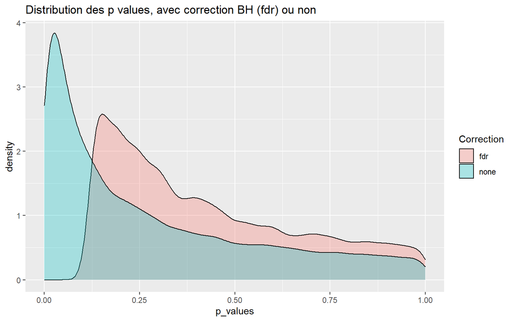

```r
d <- data.frame(p_values = c(pvals, fdr), Correction = c(rep("none", length(pvals)),
    rep("fdr", length(fdr))))


p <- ggplot(data = d, aes(x = p_values, fill = Correction)) + geom_density(alpha = 0.3)

p + ggtitle("Distribution des p values, avec correction BH (fdr) ou non")
```

On constate que toutes les pvalues, après correction, sont shiftées, et on n’en a quasi plus de significatives si on prend des seuils classiques autour de 5, 10 ou 1%…

# Distribution des valeurs d’importance

On s’attend à voir une distribution des TFs plus étalée vers de fortes importances que ne le serait celle des variables espionnes.

C’est en effet ce que l’on constate :

```r
print(head(tfs))
```

```
[1] 0.007949825 0.010367282 0.003644689 0.010224488 0.002812609 0.001253807
```

```r
print(head(spies))
```

```
[1] 0.005986270 0.013794800 0.002586615 0.001242837 0.001790762 0.005034747
```

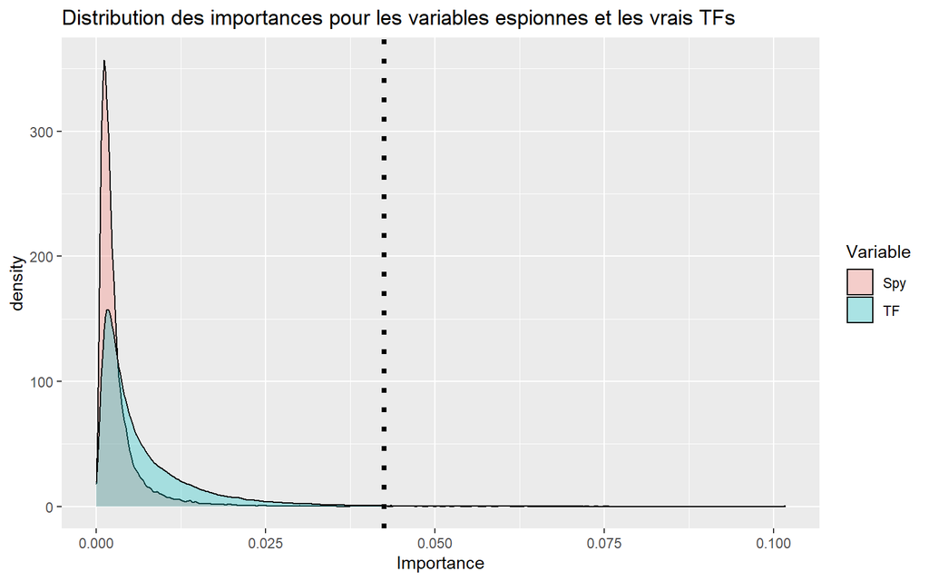

```r
d <- data.frame(Importance = c(tfs, spies), Variable = c(rep("TF", length(tfs)),
    rep("Spy", length(spies))))

p <- ggplot(data = d, aes(x = Importance, fill = Variable)) + geom_density(alpha = 0.3) +
    geom_vline(xintercept = quantile(spies, probs = 1 - pval), linetype = "dotted",
        size = 1.5)

p + ggtitle("Distribution des importances pour les variables espionnes et les vrais TFs")
```

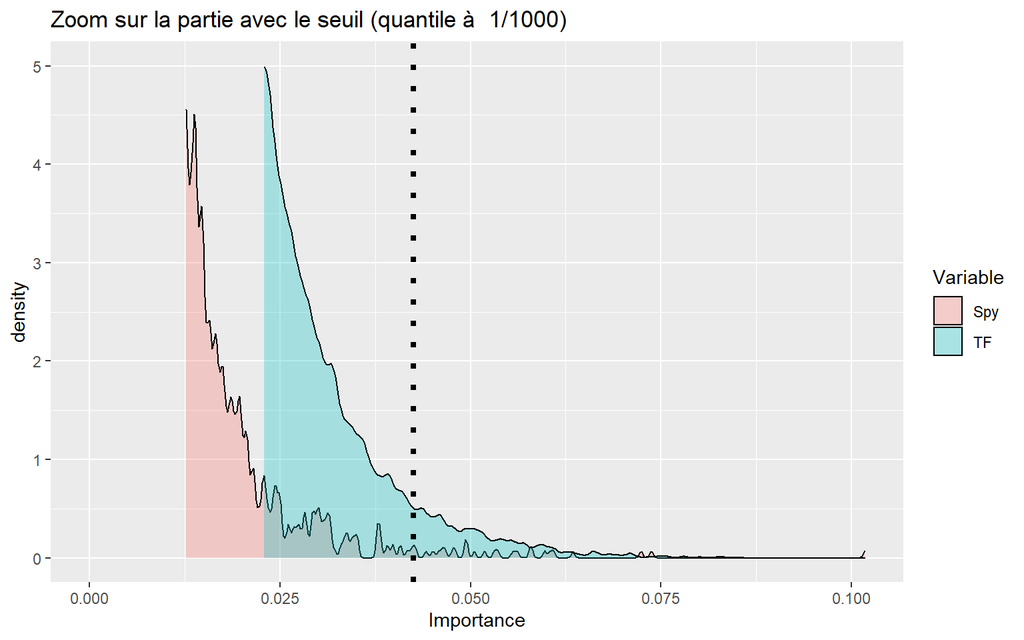

```r
p + ylim(c(0, 5)) + ggtitle("Zoom sur la partie avec le seuil (quantile à  1/1000)")
```

On note que comparé au nombre total possible d’arrêtes (176 000), on en sélectionne très peu.

# Variance des variables espionnes : sont-elles de “vraies” espionnes?

Si les variables espionnes générées avec une loi de Poisson ne sont en fait pas aussi dispersées que les valeurs d’expression des vrais TFs, cela pourrait les différencier, et donc biaiser notre méthode. On affiche donc leur variance pour s’en rendre compte, comparé à celle des TFs :

```r
exp <- insertSpyVariable(normalized.count, regressors = intersect(TF$AGI, genes),
    n_spies = 135, keepColMeans = F)
```

```
        cNF_3 cNF_2 cNF_1 cnF_2 cnF_1 cnF_3 CNF_1 CnF_2 CnF_1 CnF_3 CNF_3 CNF_2
spy_130  1197  1255  1181  1216  1293  1188  1208  1204  1180  1253  1189  1223
spy_131  1227  1254  1252  1274  1208  1247  1121  1195  1207  1229  1195  1163
spy_132  1187  1201  1241  1223  1236  1213  1188  1269  1193  1255  1241  1233
spy_133  1212  1184  1188  1201  1230  1203  1228  1188  1238  1180  1160  1253
spy_134  1198  1234  1228  1202  1178  1248  1198  1205  1230  1225  1240  1183
spy_135  1253  1234  1140  1181  1251  1190  1267  1258  1253  1200  1192  1197
```

```r
exp <- exp[rownames(exp) %in% intersect(TF$AGI, genes) | grepl("spy_", rownames(exp)),
    ]

vars <- rowSds(exp)^2
tfs_vars <- vars[names(vars) %in% intersect(TF$AGI, genes)]
spy_vars <- vars[!names(vars) %in% intersect(TF$AGI, genes)]

spy_means <- rowMeans(exp[grepl("spy", rownames(exp)), ])
summary(spy_means)
```

```
   Min. 1st Qu.  Median    Mean 3rd Qu.    Max.
   1198    1214    1220    1220    1226    1247
```

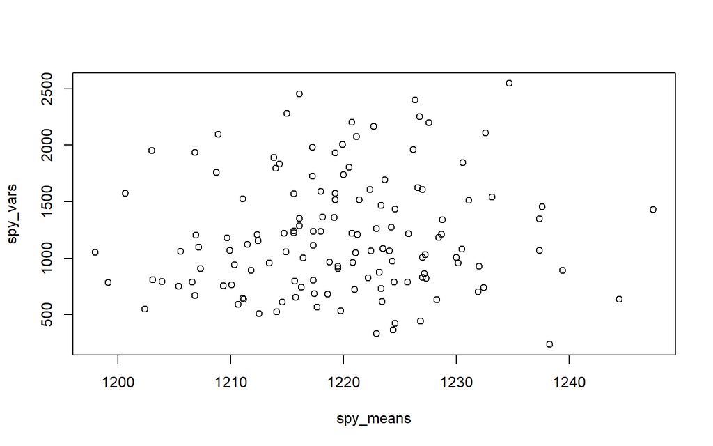

```r
plot(spy_means, spy_vars)
```

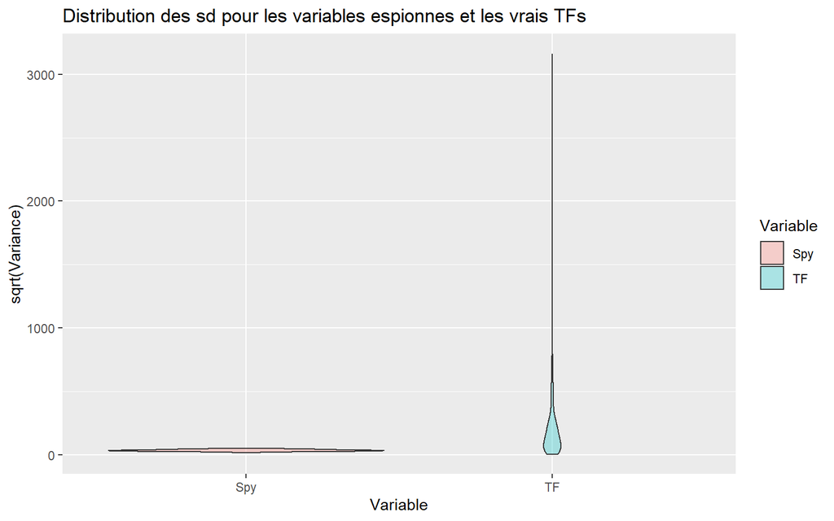

```r
d <- data.frame(Variance = c(tfs_vars, spy_vars), Variable = c(rep("TF", length(tfs_vars)),
    rep("Spy", length(spy_vars))))

p <- ggplot(data = d, aes(y = sqrt(Variance), x = Variable, fill = Variable)) + geom_violin(alpha = 0.3)

p + ggtitle("Distribution des sd pour les variables espionnes et les vrais TFs")
```

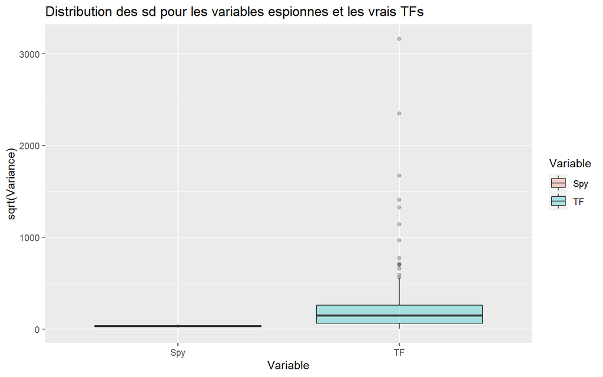

```r
p <- ggplot(data = d, aes(y = sqrt(Variance), x = Variable, fill = Variable)) + geom_boxplot(alpha = 0.3)

p + ggtitle("Distribution des sd pour les variables espionnes et les vrais TFs")
```

```r
summary(spy_vars)
```

```
   Min. 1st Qu.  Median    Mean 3rd Qu.    Max.
  237.7   796.0  1085.2  1200.2  1532.2  2546.1
```

```r
summary(tfs_vars)
```

```
    Min.  1st Qu.   Median     Mean  3rd Qu.     Max.
      25     3862    21537   239582    68353 10007806
```

En effet! les variaances sont beaucoup plus petites, notre méthode ne parvient donc pas à créer des variables ressemblantes aux vrais TFs d’un point de vue de leur dispersion. Cela peut ensuite favoriser leur utilisation ou non dans les random forests. On choisit donc plutôt d’échantillonner les espionnes dans les valeurs d’epxression des TFs existants, pour avoir une distribution similaire (qui devrait ressembler plutôt à une négative binomiale) :

```r
insertSpyVariableEmprical <- function(normalized.count, regressors = row.names(normalized.count),
    n_spies = 12, keepColMeans = T) {

    tfs_expressions <- as.vector(normalized.count[regressors, ])

    spies <- data.frame(normalized.count[sample(rownames(normalized.count), size = n_spies),
        ], row.names = paste0("spy_", seq(1:n_spies)))

    for (cond in colnames(normalized.count)) {
        spies[, cond] <- sample(tfs_expressions, size = n_spies)
    }


    normalized.count <- rbind.data.frame(normalized.count, spies)
    print(tail(normalized.count))
    return(normalized.count)
}


exp <- insertSpyVariableEmprical(normalized.count, regressors = intersect(TF$AGI,
    genes), n_spies = 30)
```

```
           cNF_3      cNF_2     cNF_1     cnF_2     cnF_1      cnF_3     CNF_1
spy_25 2461.5351  938.29149 2344.9361 1123.9971 1503.1260 1528.38170 3828.6197
spy_26  221.2809   86.14394  674.9114  988.9308 3112.8760 1521.51236  107.3846
spy_27  116.6316 2460.84976 1382.4920 5763.2110  978.8951   86.51475 1371.3420
spy_28 6684.2441   22.88737  179.1886 1903.8257  112.3239  628.22213  774.6680
spy_29 1313.4828 2726.16513 1117.2608 1540.6860 1485.1915  503.49808 5092.4054
spy_30  497.2963  199.01237  182.3694 2166.1099 2684.6451   72.65999  679.3487
           CnF_2     CnF_1     CnF_3      CNF_3      CNF_2
spy_25 2722.5738  345.1386  453.7720   46.05245  205.71270
spy_26 1072.0972  786.9161  187.7836  518.03734 1418.59895
spy_27  144.4941  766.3867  573.0945   55.13494  284.71885
spy_28 1903.8257 1014.2372  662.1772 1484.16777 1134.50748
spy_29  674.1347 2143.1731 1101.2582 6470.32074  104.20245
spy_30  267.3245  676.6245 1322.3632   34.97405   42.41149
```

```r
exp <- exp[rownames(exp) %in% intersect(TF$AGI, genes) | grepl("spy_", rownames(exp)),
    ]

vars <- rowSds(exp)^2
tfs_vars <- vars[names(vars) %in% intersect(TF$AGI, genes)]
spy_vars <- vars[!names(vars) %in% intersect(TF$AGI, genes)]

spy_means <- rowMeans(exp[grepl("spy", rownames(exp)), ])
summary(spy_means)
```

```
   Min. 1st Qu.  Median    Mean 3rd Qu.    Max.
  601.3   902.2  1138.9  1238.3  1437.7  2606.7
```

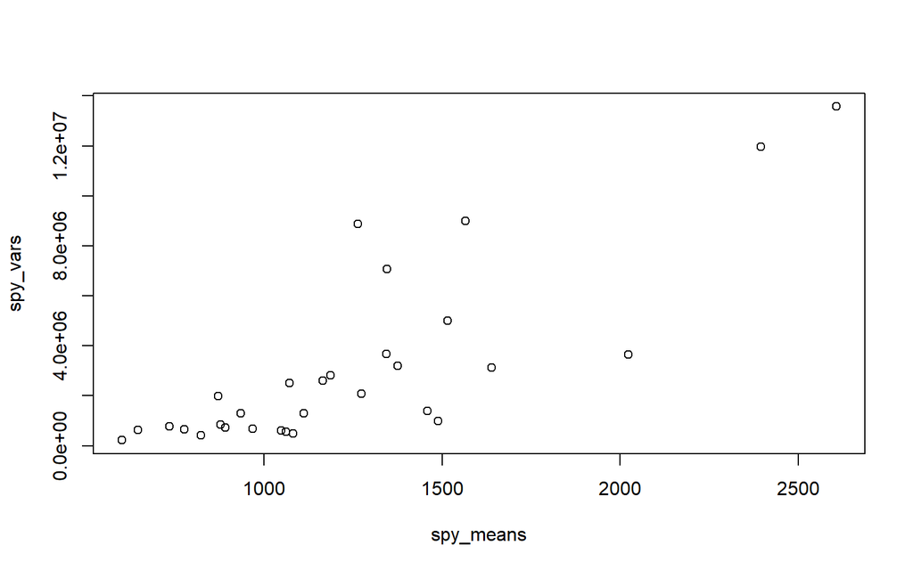

```r
plot(spy_means, spy_vars)
```

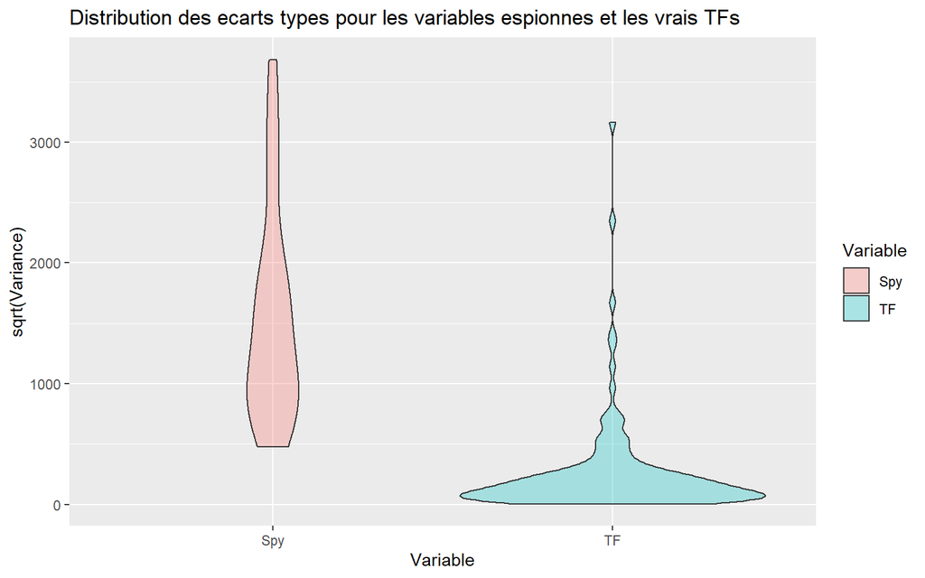

```r
d <- data.frame(Variance = c(tfs_vars, spy_vars), Variable = c(rep("TF", length(tfs_vars)),
    rep("Spy", length(spy_vars))))

p <- ggplot(data = d, aes(y = sqrt(Variance), x = Variable, fill = Variable)) + geom_violin(alpha = 0.3)

p + ggtitle("Distribution des ecarts types pour les variables espionnes et les vrais TFs")
```

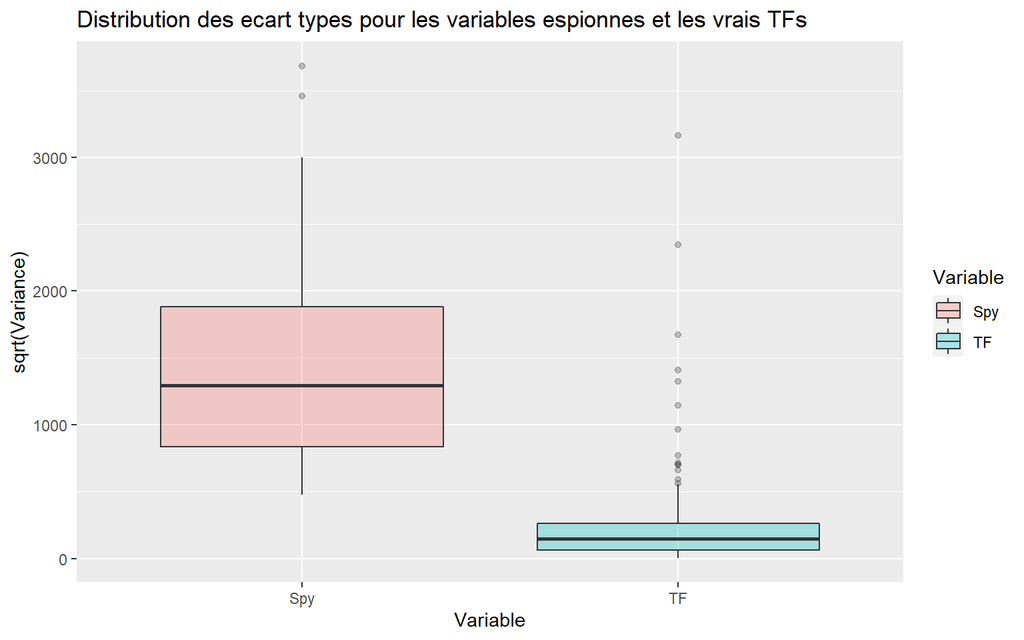

```r
p <- ggplot(data = d, aes(y = sqrt(Variance), x = Variable, fill = Variable)) + geom_boxplot(alpha = 0.3)

p + ggtitle("Distribution des ecart types pour les variables espionnes et les vrais TFs")
```

```r
summary(spy_vars)
```

```
    Min.  1st Qu.   Median     Mean  3rd Qu.     Max.
  225349   695193  1684650  3091557  3542465 13573363
```

```r
summary(tfs_vars)
```

```
    Min.  1st Qu.   Median     Mean  3rd Qu.     Max.
      25     3862    21537   239582    68353 10007806
```

Dans ce cas là, on se retrouve avec des variances de profils beaucoup plus grandes que celles des TFs. Je pense que c’est dû au fait que les valeurs d’expression moyennes entre TFs sont très différentes les unes de autres. Du coup, quand on pioche des valeurs d’expression au hasard dans les expressions des TFs, on crée des espionnes qui n’ont pas un niveau d’expression “cohérent”, car il peut prendre des valeurs très fortes ou très faibles. Il faudrait pouvoir limiter la variation de l’expression des espionnes comme l’est celle des TFs autour de leur niveau d’expression moyen… Qui est certes plus dispersé qu’une loi de Poisson, mais moins que ce que l’on obtient là. Dans ce cas là, il faudrait peut être vraiment utiliser une loi négative binomiale plutôt que de tirer les expressions de manière empirique parmis toutes les valeurs des TFs.

Par curiosité, on relance genie3 pour voir la distribution de l’importance de ces nouvelles espionnes par rapport aux vrais Tfs :

```r
# inference and thresholding
res <- genie3(normalized.count, regressors = regressors, targets = genes, varNorm = F,
    pval = pval, n_spies = 20, keepColMeans = F, new_spies = T)
```

```
           cNF_3      cNF_2     cNF_1    cnF_2      cnF_1     cnF_3     CNF_1
spy_15  218.5919 1365.42294  141.1735 917.9986 2674.16002  659.4185 1651.1432
spy_16 1241.3185  455.00087 1358.6974 212.6054   91.54947  102.1610 1841.6597
spy_17 9187.2425 4613.46861 2961.9594 160.3328  651.83507  636.3969 8193.1309
spy_18 1101.2582   69.57837 1568.6607 194.0326  115.57132  650.8653  204.1553
spy_19  571.2687  639.55351  343.7497 445.8459  988.93079  626.1047  148.3101
spy_20  109.2096   73.62957  679.3487 176.2323 2543.92908 4689.5209  408.2546
            CnF_2       CnF_1     CnF_3      CNF_3      CNF_2
spy_15 743.261440  944.716039 1443.4747 3074.66688   99.82984
spy_16 327.628795    3.681479 3445.2160   66.83111 4024.77661
spy_17  75.025762 1135.826546  162.7163  307.48333 4050.97083
spy_18   1.228044 1071.584958  344.8667 7559.84889  180.11915
spy_19 240.685231  302.801624  704.0828  305.77523 1349.26195
spy_20 544.835390 1201.082431  707.7643  167.96725  718.30220
     99.9%
0.04084172
[1] "Number of links : 1080"
```

```r
net <- res$net
length(V(net))  # nombre de genes du reseau
```

```
[1] 559
```

```r
length(E(net))  # nombre d'arretes
```

```
[1] 1080
```

```r
spies <- res$impSpies
tfs <- res$impTFs

print(head(tfs))
```

```
[1] 0.009473614 0.014950889 0.003722839 0.016579485 0.003764328 0.001286348
```

```r
print(head(spies))
```

```
[1] 0.005190764 0.003132143 0.001960793 0.001905213 0.003440474 0.002067744
```

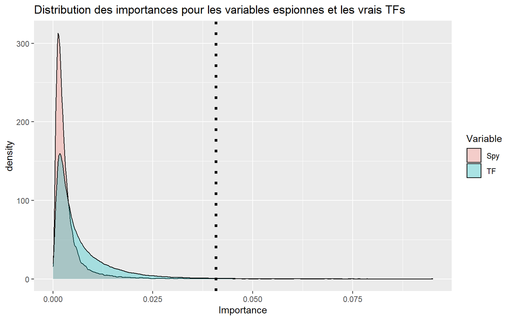

```r
d <- data.frame(Importance = c(tfs, spies), Variable = c(rep("TF", length(tfs)),
    rep("Spy", length(spies))))

p <- ggplot(data = d, aes(x = Importance, fill = Variable)) + geom_density(alpha = 0.3) +
    geom_vline(xintercept = quantile(spies, probs = 1 - pval), linetype = "dotted",
        size = 1.5)

p + ggtitle("Distribution des importances pour les variables espionnes et les vrais TFs")
```

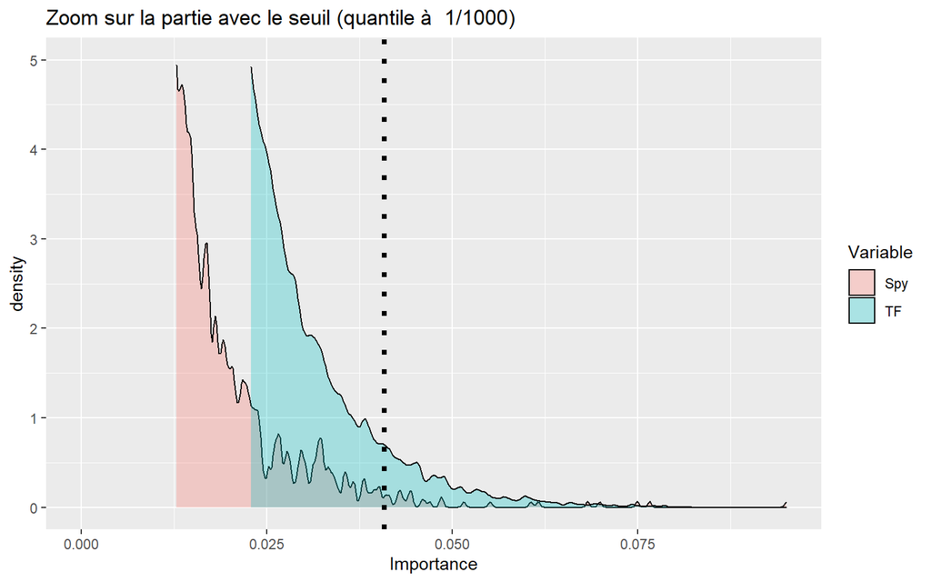

```r
p + ylim(c(0, 5)) + ggtitle("Zoom sur la partie avec le seuil (quantile à  1/1000)")
```

Dans tous les cas, on est embêté car ces variables espionnes n’ont toujours pas une variance comparable à celle des TFs, donc le test peut encore être biaisé. Il faut trouver un meilleur moyen de les générer.

# Exploration paramétrique

La méthode repose cependant sur de nombreux paramètres, et explorer leur influence est nécessaire pour faire un choix.

Nous lançons donc la méthode plusieurs fois, pour chaque set de paramètres, et regardons le nombre d’arrêtes selectionnées au final (axe y). Les paramètres sont :

- Le nombre de variables espionnes (axe x)
- Si oui ou non les profils sont tous normalisés afin d’avoir une variance unitaire. (les deux lignes du graphe)
- Si on tire les variables random dans une loi Poisson dont le paramètre est spécifique à la condition, ou si on prend la moyenne globale parmis toutes les conditions (les deux colonnes du graphe)
- Le quantile choisi, correspond à la pvalue de notre test (couleur des points)

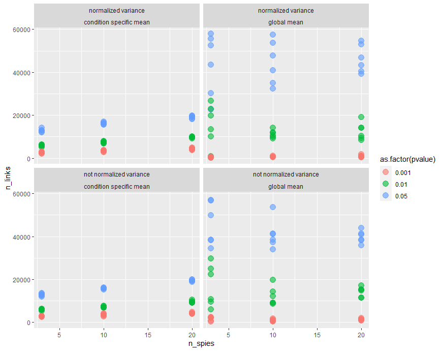

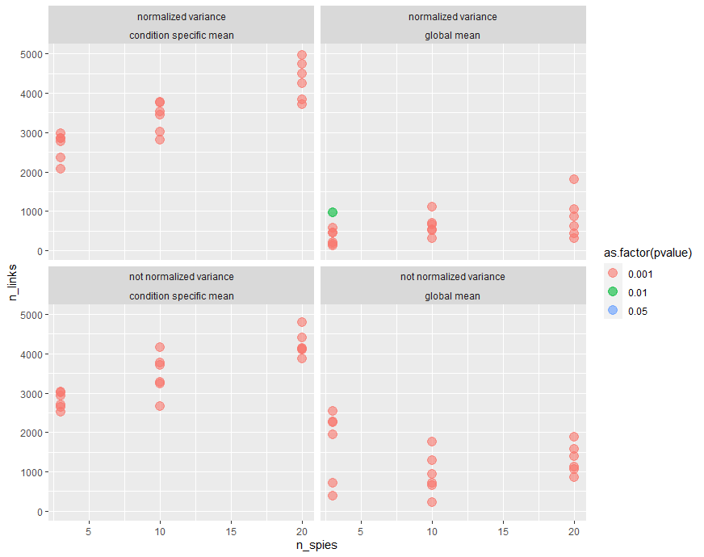

On se rend compte qu’on n’a pas vraiment d’effet de la normalisation (étudié plus bas).

Ensuite, de prendre une moyenne non dépendant des conditions donne un plus grand nombre d’arrêtes, faisant penser qu’il s’agit d’un choix moins informatif pour nos variables randoms, et donc plus proche de notre hypothèse nulle.

Il faut des quantiles assez faibles pour avoir un nombre d’arrêtes raisonnable, on peut dire qu’entre 0.005 et 0.001 on est dans une bonne zone.

Le nombre de variables espionnes semble augmenter le nombre d’arrêtes sélectionnées, je ne sais pas encore exactement pourquoi, à continuer d’explorer.

# Version seuil gene specific

La méthode proposée précédement repose sur l’hypothèse que les valeurs d’importance de toutes les paires peuvent être directement comparées, et ne dépendent pas de caractèristiques propres aux gènes, comme leur variance ou expression moyenne.

Pour s’en assurer, nous avons implémenté une méthode qui, au lieu de se baser sur un quantile d’une distribution qui merge tous les gènes cibles, se base sur un seuil par gène.

On prend, pour chaque gène, l’importance maximale trouvé parmis les n variables espionnes générées. Tous les TFs dont l’importance est supérieure à ce seuil pour ce gène sont gardés.

On refait donc une exploration paramétrique pour avec ou sans moyenne condition spécifique, pour plusieurs nombre de variables espionnes :

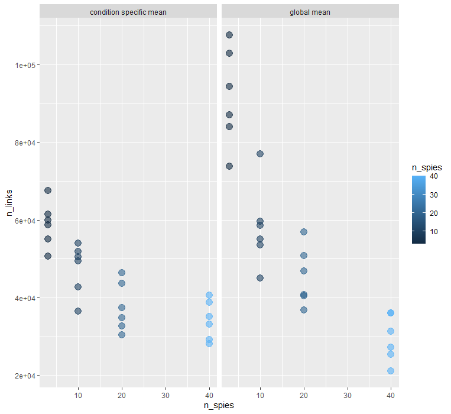

On voit tout de sute que les ordres de grandeur du nombre de links gardés dans le réseau sont beaucoup trop grands pour avoir des réseaux interprêtables facilement (100 000 arrêtes, au minimum 20 000)…

Pour s’assurer du fait que la valeur d’importance calculée par GENIE3 ne dépend pas du gène, on trace l’importance maximale des variables espionnes pour chaque gène, en fonction de son coefficient de variation :

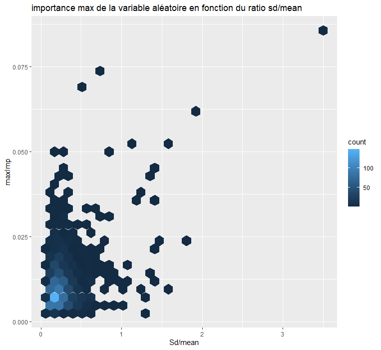

La corrélation est faible (10%), justifiant que l’on puisse utiliser une methode de seuil non spécifique au gène telle que celle présentée dans un premier temps.

# Effet de la variance normalisée

A priori, on avait vu que la variance ne change pas trop les réseaux inférés, switch des arrêtes, mais on aimerait le quantifier. De plus, dans l’exploration paramétrique précédente, elle ne changeait pas le nombre d’arrêtes.

On choisit de calculer la correlation de spearman entre un vecteur d’importances des mêmes paires, calculées avec normalisation de la variance ou non.

Avant le test, on fixe qu’une valeur supérieure à 80% serait bien, sinon pas terrible.

```r
resNorm <- genie3(normalized.count, regressors = regressors, targets = genes, varNorm = T,
    pval = pval, n_spies = 20, keepColMeans = F)
```

```
       cNF_3 cNF_2 cNF_1 cnF_2 cnF_1 cnF_3 CNF_1 CnF_2 CnF_1 CnF_3 CNF_3 CNF_2
spy_15  1210  1191  1251  1247  1301  1175  1265  1174  1187  1204  1251  1240
spy_16  1177  1248  1120  1196  1201  1213  1086  1175  1160  1182  1190  1234
spy_17  1188  1215  1268  1185  1218  1273  1235  1192  1235  1229  1210  1197
spy_18  1203  1274  1123  1270  1205  1159  1230  1237  1227  1213  1214  1253
spy_19  1198  1192  1267  1250  1216  1191  1212  1186  1222  1285  1193  1227
spy_20  1162  1272  1209  1230  1263  1208  1186  1226  1199  1190  1184  1221
     99.9%
0.04048405
[1] "Number of links : 1165"
```

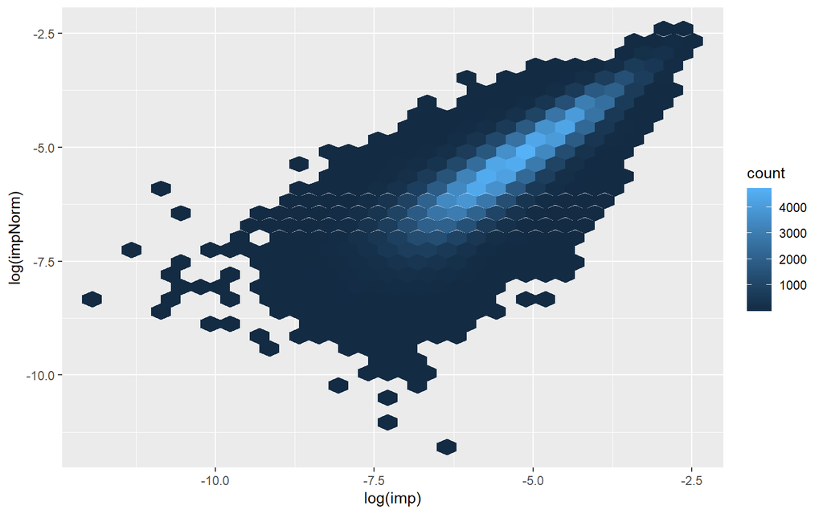

```r
tfs_norm <- resNorm$impTFs

d <- data.frame(impNorm = tfs_norm, imp = tfs)

ggplot(data = d, aes(x = log(imp), y = log(impNorm))) + geom_hex()
```

```r
cor(tfs, tfs_norm, method = "spearman")
```

```
[1] 0.8859143
```

La corrélation est très forte, au dessus des 80%!.

Cela confirme que la normalisation de la variance ne semble pas nécessaire, car GENIE3 semble déjà avoir réglé la dépendance entre gènes et valeurs d’importance avec une étape de normalisation interne. En effet, les importances pour chaque gènes sont divisées par la somme de toutes les importances de ce gène cible là.

# CONCLUSION

Au terme des simulations et des tests, il semblerait que nous puissions nous orienter vers cette méthode.

Le choix du nombre de variables espionnes est encore un peu flou, et relativement peu influent. Nous pouvons supposer qu’il est mieux de privilégier un petit nombre de variables espionnes afin de ne pas interférer avec les combinatoires de TFs inférées par GENIE3, et ne pas risquer de diminuner le ratio signal sur bruit. On pourrait partir sur 10% du nombre de TFs dans le jeu de données.

Un point négatif est qu’il reste encore pas mal de variabilité dans les réseaux finaux (en terme de nombre de connexions), car ils dépendent pas mal du tirage initial des variables randoms. Si on lance plusieurs fois la méthode avec les mêmes paramètres, le nombre de connexions du réseau final peut varier de plusieurs centaines… souvent entre 800 et 1200 arrêtes pour les paramètres utilisés lors de l’exécution. On pourrait appliquer plusieurs fois la méthode et moyenner les seuils obtenus.

**Il reste à finir de traiter la question de la correction des tests multiples, trop conservatrice à cause du très grand nombre de tests.**

Il s’agit ici d’un **test empirique** que nous avons créé pour répondre à notre problème. Au lieu de connaître théoriquement le distribution de l’importance du bruit de fond, ou background, des données, nous l’avons générée en introduisant des variables qui nous avons simulées sous cette hypothèse nulle.

Les résultats restent sujets à des choix pas toujours triviaux en termes de valeurs de paramètres, mais la sortie de notre méthode est plus interprêtable et utilisable que du hard thresholding. En effet, plutôt que de fixer un seuil sur une valeur d’importance issue d’un random forest à priori peu parlante, nous pouvons travailler avec des pvalues, traduisant plus correctement notre volonté de stringeance.

Cela semble être une bonne base pour commencer à analyser et interprêter le réseau en des termes plus biologiques!